# Neuauswertung der ZfS-Analysen

Nader Hotait - Universität Potsdam - nhotait@uni-potsdam.de<

17 Januar, 2021

# Vorab-Infos

Die folgenden Daten habe ich neu aus dem Web-of-Science gezogen. Heißt: Auch unsere ursprüngliche Rechnung (**Modell 7**) hat sich in Fallzahl geändert - von knapp 190 auf 300! Die meisten der hinzugekommenen Papers handeln über Covid. Das war irgendwie abzusehen. Ich gehe auch verschiedene Daten-Konstellationen aus dem Web-of Science ein. Bei jedem Modell ist die Datenbank, Suchbegriffe und die Fallzahl vermerkt. Zur Erinnerung: ∨ heißt “oder”, ∧ heißt “und”. Die hinzunahme von den vorgeschlagenen Wörtern findet in **Modell 8** statt. Die anderen Modelle sind unterschiedliche Kombinationen und Datensätze.

[Ich versuche empirisch die beste Zahl der Topics zu ermitteln.](https://cran.r-project.org/web/packages/ldatuning/vignettes/topics.html) Dabei kommen vier Angaben vor, von denen jeweils zwei zu minimieren und maximieren sind:

Für Modelle wo ich es wichtig finde, stelle ich auch die Top10 Wörter der jeweiligen Topics dar. **Wichtig: Diese Berechnungen sind nur Hilfen. Jeder Data Scientist stimmt hier überein: Es gibt kein goodness-of-fit, welches uns schlagende Ergebnisse geben kann oder sollte. Beim Topic Modelling, wie auch anderen ähnlichen Analyseverfahren, geht es um die Fähigkeit des Betrachters die Cluster auch interpretieren zu können.**

# Modell 1

**Datenbank**: SSCI  
**Search Terms**: (digital* ∨ online* ∨ internet*) ∧ ineq*  
**Fallzahl**: 2.578

## Datenpräperation

```r
# Wir kreieren den zu modellieren Text aus Titel und Abstrakt
ssci_3_ineq <- readRDS("D:/Office/Arbeit/pubs/zfs/ssci_3_ineq/ssci_3_ineq.rds")
ssci_3_ineq$text <- paste(ssci_3_ineq$ti, ssci_3_ineq$ab, sep=" ") ## Concat.
mod1_text <- ssci_3_ineq$text ## Als eigener Vektor

# Hier wird sauber gemacht
mod1_text  <- tolower(mod1_text) ## Kleinbuchstaben
mod1_text  <-  removeWords(mod1_text, tm::stopwords("en")) ## Remove stopwords
print(tm::stopwords("en")) ## Folgende stopwords wurden entfernt
```

```
##   [1] "i"          "me"         "my"         "myself"     "we"
##   [6] "our"        "ours"       "ourselves"  "you"        "your"
##  [11] "yours"      "yourself"   "yourselves" "he"         "him"
##  [16] "his"        "himself"    "she"        "her"        "hers"
##  [21] "herself"    "it"         "its"        "itself"     "they"
##  [26] "them"       "their"      "theirs"     "themselves" "what"
##  [31] "which"      "who"        "whom"       "this"       "that"
##  [36] "these"      "those"      "am"         "is"         "are"
##  [41] "was"        "were"       "be"         "been"       "being"
##  [46] "have"       "has"        "had"        "having"     "do"
##  [51] "does"       "did"        "doing"      "would"      "should"
##  [56] "could"      "ought"      "i'm"        "you're"     "he's"
##  [61] "she's"      "it's"       "we're"      "they're"    "i've"
##  [66] "you've"     "we've"      "they've"    "i'd"        "you'd"
##  [71] "he'd"       "she'd"      "we'd"       "they'd"     "i'll"
```

[output cut: 20 more lines]

```r
mod1_text  <-  gsub("’", "'", mod1_text) ## Falsche Apostrophe ausgetauscht
mod1_text  <-  gsub("-", " ", mod1_text) ## Bindestriche mit Leerzeichen ausgetauscht
mod1_text  <-  gsub("[\r\n]", "", mod1_text) ## Zeilenumbrüche entfernt
mod1_text  <-  gsub("[[:punct:]]", "", mod1_text) ## Sonderzeichen entfernt
mod1_text  <-  gsub("covid 19", "covid19", mod1_text) ## Spezialfall
mod1_text  <-  gsub("[[:digit:]]+", "", mod1_text) ## Zahlen entfernt
mod1_text  <- str_squish(mod1_text) ## Doppelte Leerzeichen entfernt

# Umwandlung in Dokument-Term-Matrx(DTM)
corp <- Corpus(VectorSource(mod1_text))
dtm <- DocumentTermMatrix(corp)

# Angemessene Zahl an Topics finden
result <- FindTopicsNumber(
  dtm,
  topics = seq(from = 2, to = 15, by = 1),
  metrics = c("Griffiths2004", "CaoJuan2009", "Arun2010", "Deveaud2014"),
  method = "Gibbs",
  control = list(seed = 77),
  mc.cores = 4L,
  verbose = TRUE
)
```

```
## fit models... done.
## calculate metrics:
##   Griffiths2004... done.
##   CaoJuan2009... done.
##   Arun2010... done.
##   Deveaud2014... done.
```

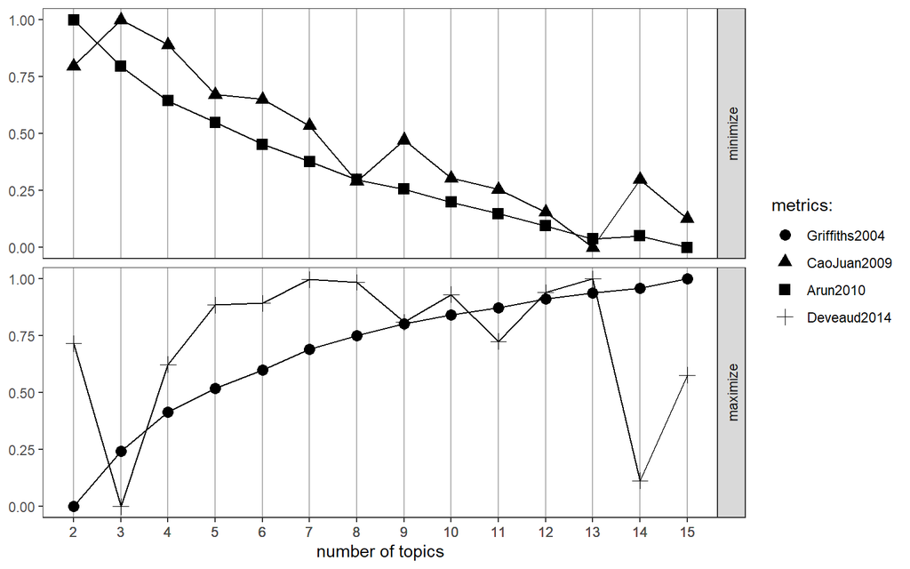

```r
FindTopicsNumber_plot(result)
```

```r
## 13 Topics scheinen am besten
```

## Topic-Modelling

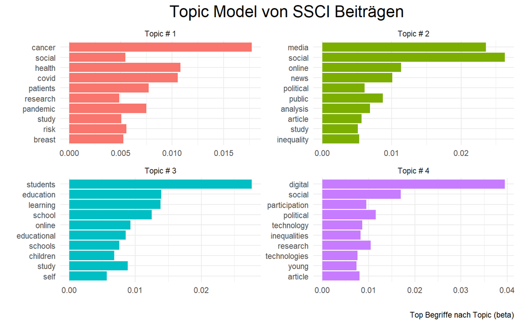

```r
# LDA
topics <- LDA(dtm, k = 13, control = list(seed = 77))

# Clean-Up/Beta(also Prob.) extrahieren
wos_topics <- tidy(topics, matrix="beta")

# Top-10 Wörter je Topic
wos_top_terms <-
  wos_topics %>%
  group_by(topic) %>%
  top_n(10, beta) %>%
  ungroup() %>%
  arrange(topic, -beta)

# Darstellung
wos_top_terms[1:40,] %>%
  mutate(term=reorder(term, beta)) %>%
  mutate(topic = paste("Topic #", topic)) %>%
  ggplot(aes(term, beta, fill=factor(topic))) +
  geom_col(show.legend = FALSE) +
  facet_wrap(~ topic, scales="free") +
  theme_minimal()+
  theme(plot.title =
          element_text(hjust=0.5, size=18)) +
  labs(title = "Topic Model von SSCI Beiträgen",
       caption = "Top Begriffe nach Topic (beta)"
       ) +
  ylab("") +
  xlab("") +
  coord_flip()
```

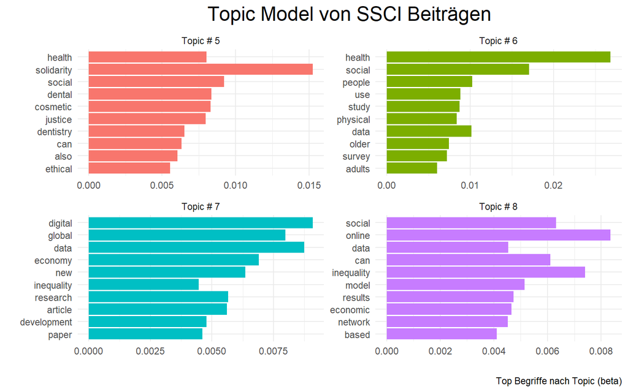

```r
wos_top_terms[41:80,] %>%
  mutate(term=reorder(term, beta)) %>%
  mutate(topic = paste("Topic #", topic)) %>%
  ggplot(aes(term, beta, fill=factor(topic))) +
  geom_col(show.legend = FALSE) +
  facet_wrap(~ topic, scales="free") +
  theme_minimal()+
  theme(plot.title =
          element_text(hjust=0.5, size=18)) +
  labs(title = "Topic Model von SSCI Beiträgen",
       caption = "Top Begriffe nach Topic (beta)"
       ) +
  ylab("") +
  xlab("") +
  coord_flip()
```

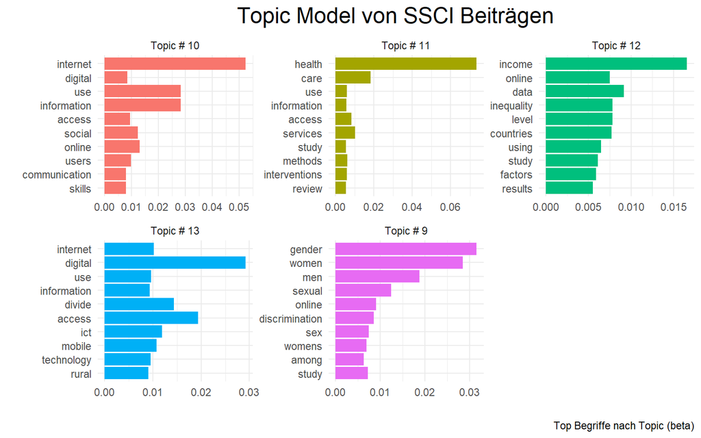

```r
wos_top_terms[81:nrow(wos_top_terms),] %>%
  mutate(term=reorder(term, beta)) %>%
  mutate(topic = paste("Topic #", topic)) %>%
  ggplot(aes(term, beta, fill=factor(topic))) +
  geom_col(show.legend = FALSE) +
  facet_wrap(~ topic, scales="free") +
  theme_minimal()+
  theme(plot.title =
          element_text(hjust=0.5, size=18)) +
  labs(title = "Topic Model von SSCI Beiträgen",
       caption = "Top Begriffe nach Topic (beta)"
       ) +
  ylab("") +
  xlab("") +
  coord_flip()
```

# Modell 2

**Datenbank**: SSCI  
**Search Terms**: (digital* ∨ online* ∨ internet*) ∧ (ineq* ∨ diversity ∨ intersectional*)  
**Fallzahl**: 5.648

## Datenpräperation

```r
# Wir kreieren den zu modellieren Text aus Titel und Abstrakt
rm(list = ls())
ssci_3_ineq3 <- readRDS("D:/Office/Arbeit/pubs/zfs/ssci_3_ineq3/ssci_3_ineq3.rds")
ssci_3_ineq3$text <- paste(ssci_3_ineq3$ti, ssci_3_ineq3$ab, sep=" ") ## Concat.
mod2_text <- ssci_3_ineq3$text ## Als eigener Vektor

# Hier wird sauber gemacht
mod2_text  <- tolower(mod2_text) ## Kleinbuchstaben
mod2_text  <-  removeWords(mod2_text, tm::stopwords("en")) ## Remove stopwords
mod2_text  <-  gsub("’", "'", mod2_text) ## Falsche Apostrophe ausgetauscht
mod2_text  <-  gsub("-", " ", mod2_text) ## Bindestriche mit Leerzeichen ausgetauscht
mod2_text  <-  gsub("[\r\n]", "", mod2_text) ## Zeilenumbrüche entfernt
mod2_text  <-  gsub("[[:punct:]]", "", mod2_text) ## Sonderzeichen entfernt
mod2_text  <-  gsub("covid 19", "covid19", mod2_text) ## Spezialfall
mod2_text  <-  gsub("[[:digit:]]+", "", mod2_text) ## Zahlen entfernt
mod2_text  <- str_squish(mod2_text) ## Doppelte Leerzeichen entfernt

# Umwandlung in Dokument-Term-Matrx(DTM)
corp <- Corpus(VectorSource(mod2_text))
dtm <- DocumentTermMatrix(corp)

# Angemessene Zahl an Topics finden. Vorabtest ergab 20 als optimale Zahl. Wir testen das mal!
result <- FindTopicsNumber(
  dtm,
  topics = seq(from = 20, to = 40, by = 1),
  metrics = c("Griffiths2004", "CaoJuan2009", "Arun2010", "Deveaud2014"),
  method = "Gibbs",
  control = list(seed = 77),
  mc.cores = 4L,
  verbose = TRUE
)
```

```
## fit models... done.
## calculate metrics:
##   Griffiths2004... done.
##   CaoJuan2009... done.
##   Arun2010... done.
##   Deveaud2014... done.
```

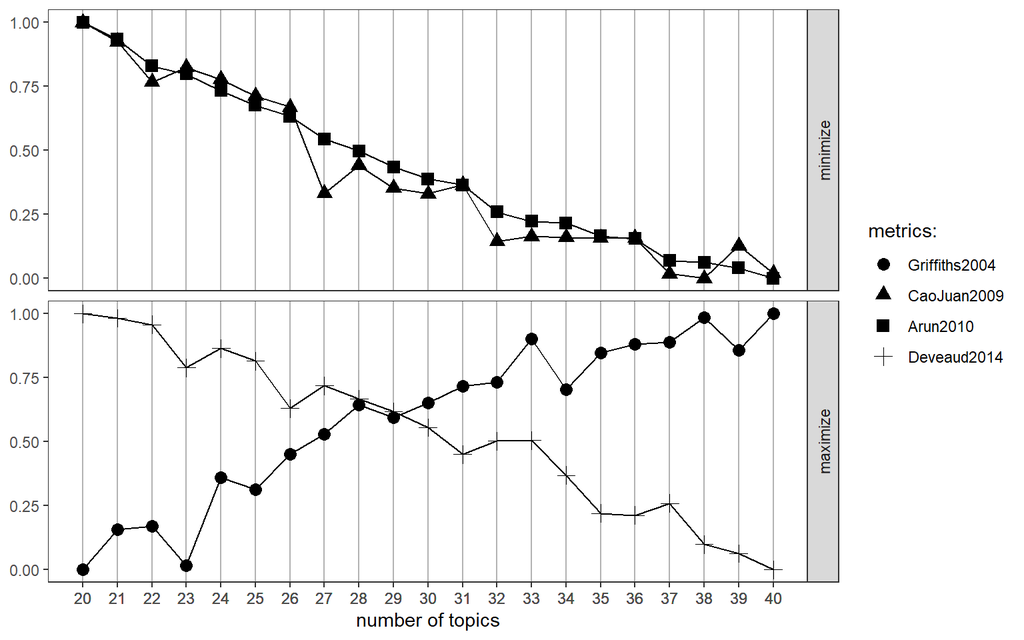

```r
FindTopicsNumber_plot(result)
```

```r
## 38 o. 40 Topics scheinen am besten
```

## Topic-Modelling

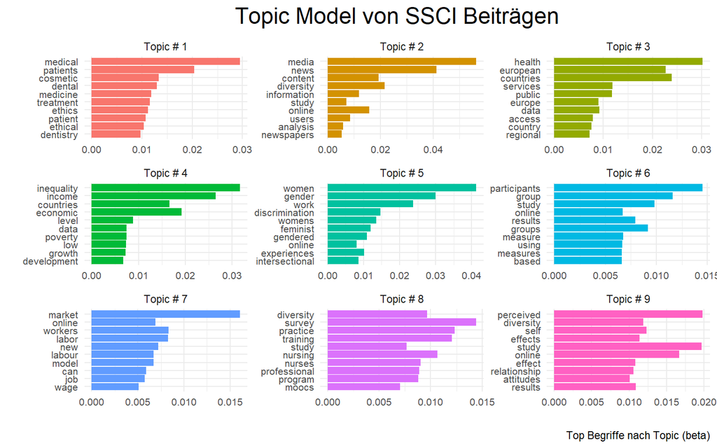

```r
# LDA
topics <- LDA(dtm, k = 38, control = list(seed = 77))

# Clean-Up/Beta(also Prob.) extrahieren
wos_topics <- tidy(topics, matrix="beta")

# Top-10 Wörter je Topic
wos_top_terms <-
  wos_topics %>%
  group_by(topic) %>%
  top_n(10, beta) %>%
  ungroup() %>%
  arrange(topic, -beta)

# Darstellung
wos_top_terms[1:90,] %>%
  mutate(term=reorder(term, beta)) %>%
  mutate(topic = paste("Topic #", topic)) %>%
  ggplot(aes(term, beta, fill=factor(topic))) +
  geom_col(show.legend = FALSE) +
  facet_wrap(~ topic, scales="free") +
  theme_minimal()+
  theme(plot.title =
          element_text(hjust=0.5, size=18)) +
  labs(title = "Topic Model von SSCI Beiträgen",
       caption = "Top Begriffe nach Topic (beta)"
       ) +
  ylab("") +
  xlab("") +
  theme(axis.text=element_text(size=8)) +
  coord_flip()
```

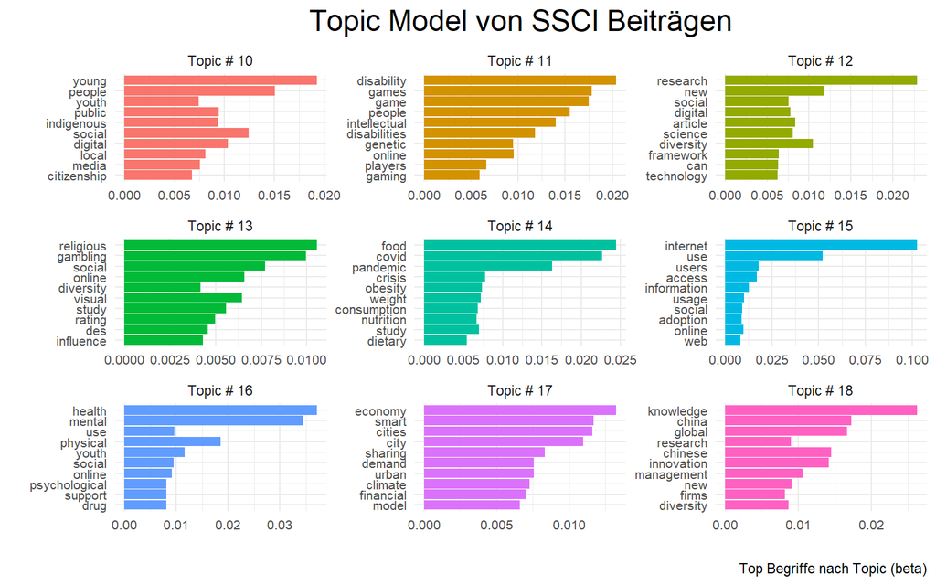

```r
wos_top_terms[91:180,] %>%
  mutate(term=reorder(term, beta)) %>%
  mutate(topic = paste("Topic #", topic)) %>%
  ggplot(aes(term, beta, fill=factor(topic))) +
  geom_col(show.legend = FALSE) +
  facet_wrap(~ topic, scales="free") +
  theme_minimal()+
  theme(plot.title =
          element_text(hjust=0.5, size=18)) +
  labs(title = "Topic Model von SSCI Beiträgen",
       caption = "Top Begriffe nach Topic (beta)"
       ) +
  ylab("") +
  xlab("") +
  theme(axis.text=element_text(size=8)) +
  coord_flip()
```

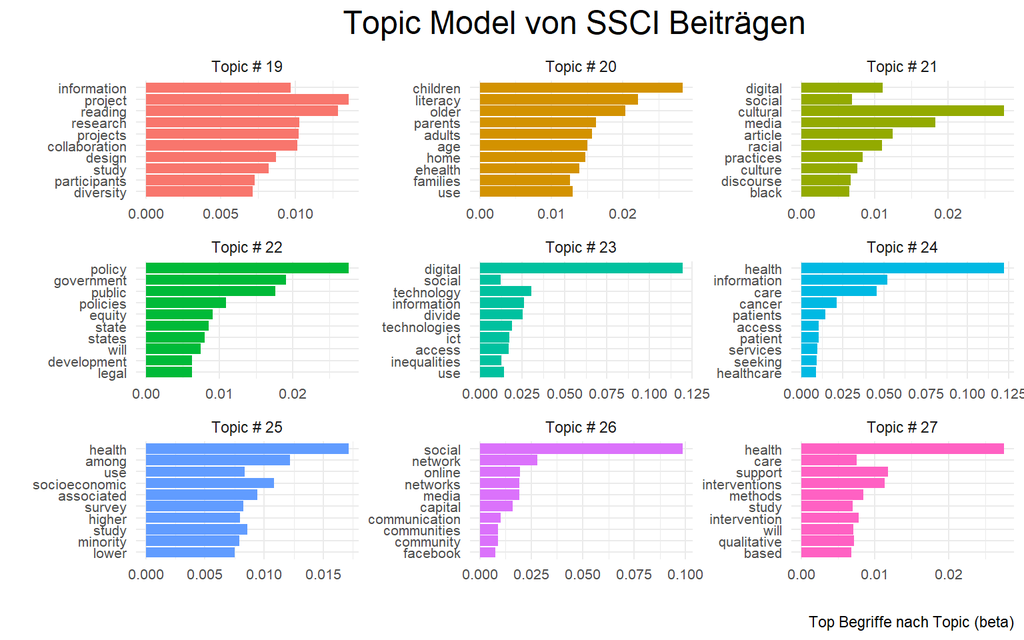

```r
wos_top_terms[181:270,] %>%
  mutate(term=reorder(term, beta)) %>%
  mutate(topic = paste("Topic #", topic)) %>%
  ggplot(aes(term, beta, fill=factor(topic))) +
  geom_col(show.legend = FALSE) +
  facet_wrap(~ topic, scales="free") +
  theme_minimal()+
  theme(plot.title =
          element_text(hjust=0.5, size=18)) +
  labs(title = "Topic Model von SSCI Beiträgen",
       caption = "Top Begriffe nach Topic (beta)"
       ) +
  ylab("") +
  xlab("") +
  theme(axis.text=element_text(size=8)) +
  coord_flip()
```

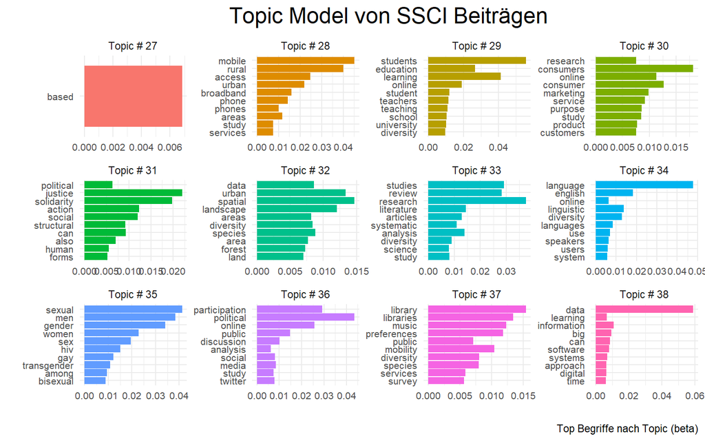

```r
wos_top_terms[270:nrow(wos_top_terms),] %>%
  mutate(term=reorder(term, beta)) %>%
  mutate(topic = paste("Topic #", topic)) %>%
  ggplot(aes(term, beta, fill=factor(topic))) +
  geom_col(show.legend = FALSE) +
  facet_wrap(~ topic, scales="free") +
  theme_minimal()+
  theme(plot.title =
          element_text(hjust=0.5, size=18)) +
  labs(title = "Topic Model von SSCI Beiträgen",
       caption = "Top Begriffe nach Topic (beta)"
       ) +
  ylab("") +
  xlab("") +
  theme(axis.text=element_text(size=8)) +
  coord_flip()
```

# Modell 3

**Datenbank**: SSCI  
**Search Terms**: (digital* ∨ online* ∨ internet*) ∧ (ineq* ∨ diversity ∨ intersectional* ∨ unequal*)  
**Fallzahl**: 5.875

**Aufgrund der Fallzahl verzichte ich ab hier auf die Darstellung von Daten mit gleicher oder größerer Fallzahl!**

## Datenpräperation und Topic-Zahl-Bestimmung Model 3

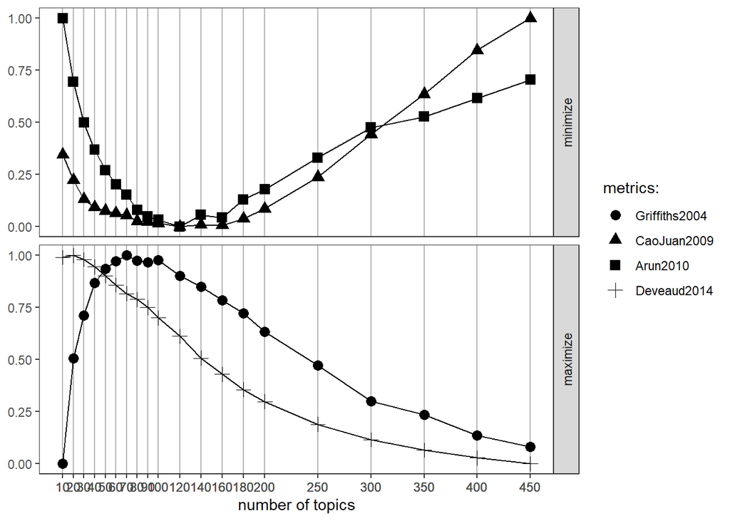

Model 3

```r
# Wir kreieren den zu modellieren Text aus Titel und Abstrakt
rm(list = ls())
ssci_3_ineq4 <- readRDS("D:/Office/Arbeit/pubs/zfs/ssci_3_ineq4/ssci_3_ineq4.rds")
ssci_3_ineq4$text <- paste(ssci_3_ineq4$ti, ssci_3_ineq4$ab, sep=" ") ## Concat.
mod3_text <- ssci_3_ineq4$text ## Als eigener Vektor

# Hier wird sauber gemacht
mod3_text  <- tolower(mod3_text) ## Kleinbuchstaben
mod3_text  <-  removeWords(mod3_text, tm::stopwords("en")) ## Remove stopwords
mod3_text  <-  gsub("’", "'", mod3_text) ## Falsche Apostrophe ausgetauscht
mod3_text  <-  gsub("-", " ", mod3_text) ## Bindestriche mit Leerzeichen ausgetauscht
mod3_text  <-  gsub("[\r\n]", "", mod3_text) ## Zeilenumbrüche entfernt
mod3_text  <-  gsub("[[:punct:]]", "", mod3_text) ## Sonderzeichen entfernt
mod3_text  <-  gsub("covid 19", "covid19", mod3_text) ## Spezialfall
mod3_text  <-  gsub("[[:digit:]]+", "", mod3_text) ## Zahlen entfernt
mod3_text  <- str_squish(mod3_text) ## Doppelte Leerzeichen entfernt

# Umwandlung in Dokument-Term-Matrx(DTM)
corp <- Corpus(VectorSource(mod3_text))
dtm <- DocumentTermMatrix(corp)

# Orientiert an dem Korpus zuvor machen wir die Themenfindung breiter.
result <- FindTopicsNumber(
  dtm,
  topics = c(seq(from = 10, to = 100, by = 10), seq(from = 120, to = 200, by = 20), seq(from = 250, to = 450, by = 50)),
  metrics = c("Griffiths2004", "CaoJuan2009", "Arun2010", "Deveaud2014"),
  method = "Gibbs",
  control = list(seed = 77),
  mc.cores = 4L,
  verbose = TRUE
)

FindTopicsNumber_plot(result)
# 70-100 Topics!
```

# Modell 4

**Datenbank**: SSCI  
**Search Terms**: (digital* ∨ online* ∨ internet*) ∧ (ineq* ∨ diversity ∨ intersectional* ∨ unequal* ∨ “digital divide”)  
**Fallzahl**: 8.088

**Aufgrund der Fallzahl verzichte ich ab hier auf die Darstellung von Daten mit gleicher oder größerer Fallzahl!**

## Datenpräperation und Topic-Zahl-Bestimmung Model 4

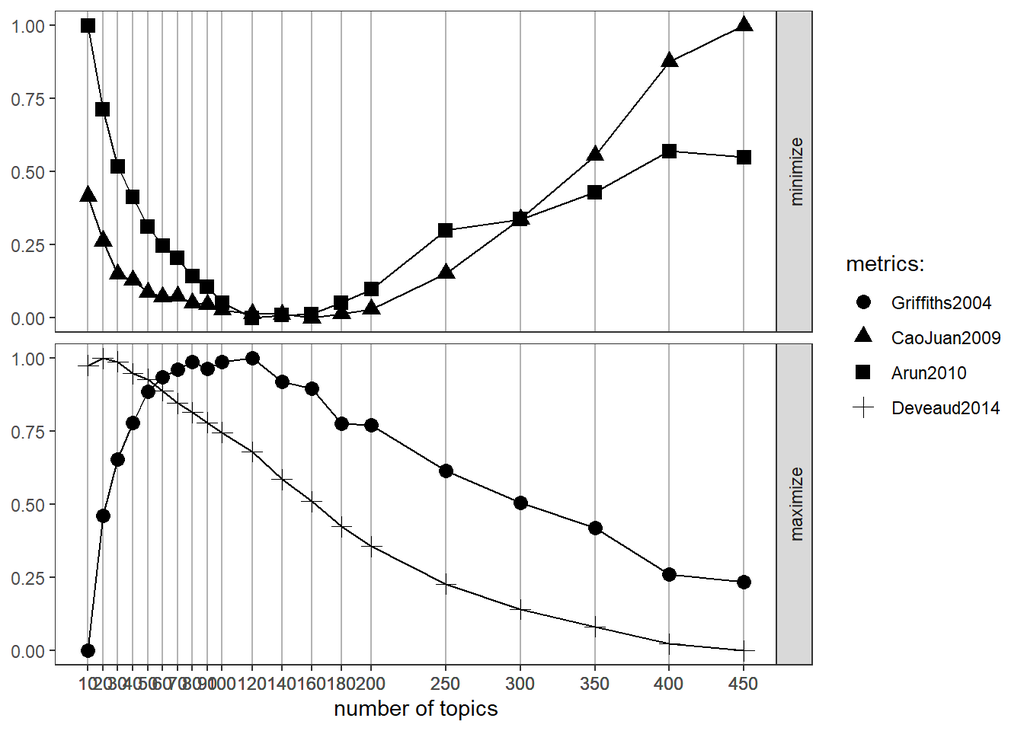

Model 4

```r
# Wir kreieren den zu modellieren Text aus Titel und Abstrakt
rm(list = ls())
ssci_3_ineq4_digital_divide <- readRDS("D:/Office/Arbeit/pubs/zfs/ssci_3_ineq4-digital divide/ssci_3_ineq4-digital divide.rds")
ssci_3_ineq4_digital_divide$text <- paste(ssci_3_ineq4_digital_divide$ti, ssci_3_ineq4_digital_divide$ab, sep=" ") ## Concat.
mod4_text <- ssci_3_ineq4_digital_divide$text ## Als eigener Vektor

# Hier wird sauber gemacht
mod4_text  <- tolower(mod4_text) ## Kleinbuchstaben
mod4_text  <-  removeWords(mod4_text, tm::stopwords("en")) ## Remove stopwords
mod4_text  <-  gsub("’", "'", mod4_text) ## Falsche Apostrophe ausgetauscht
mod4_text  <-  gsub("-", " ", mod4_text) ## Bindestriche mit Leerzeichen ausgetauscht
mod4_text  <-  gsub("[\r\n]", "", mod4_text) ## Zeilenumbrüche entfernt
mod4_text  <-  gsub("[[:punct:]]", "", mod4_text) ## Sonderzeichen entfernt
mod4_text  <-  gsub("covid 19", "covid19", mod4_text) ## Spezialfall
mod4_text  <-  gsub("[[:digit:]]+", "", mod4_text) ## Zahlen entfernt
mod4_text  <- str_squish(mod4_text) ## Doppelte Leerzeichen entfernt

# Umwandlung in Dokument-Term-Matrx(DTM)
corp <- Corpus(VectorSource(mod4_text))
dtm <- DocumentTermMatrix(corp)

# Orientiert an dem Korpus zuvor machen wir die Themenfindung breiter.
result <- FindTopicsNumber(
  dtm,
  topics = c(seq(from = 10, to = 100, by = 10), seq(from = 120, to = 200, by = 20), seq(from = 250, to = 450, by = 50)),
  metrics = c("Griffiths2004", "CaoJuan2009", "Arun2010", "Deveaud2014"),
  method = "Gibbs",
  control = list(seed = 77),
  mc.cores = 4L,
  verbose = TRUE
)

FindTopicsNumber_plot(result)
# 120 Topics
```